# R Notebook

Martin Selvek Na spracovanie som si vybral dáta o vplyve plazmou aktivovanej vody na rast klíčkov kukurice. Nakoľko tieto dáta ešte len rastú, vymyslel som si ich v exceli spôsobom: (stredná hodnota)+Random(odchylka)-Random(odchylka). Pozitím dvoch rovnomerných random generatorov dostaneme rozlozenie tvaru striešky, čo je prvý krok ku normálnemu rozdeleniu. 4 randomy by boli lepšie, ale dostať od kukurice perfektné dáta nebude ľahké tiež, tak si vystačíme s dvoma.

## Import dát

Využijeme importer.

```r
library(readxl)
url <- "https://github.com/mselvek/skuskovy_projekt/blob/master/kukurica_data.xlsx?raw=true"
destfile <- "kukurica_data.xlsx"
curl::curl_download(url, destfile)
kukurica_data <- read_excel(destfile)
View(kukurica_data)
```

## Znázornenie dát

Na úvod boxploty podla odrody.

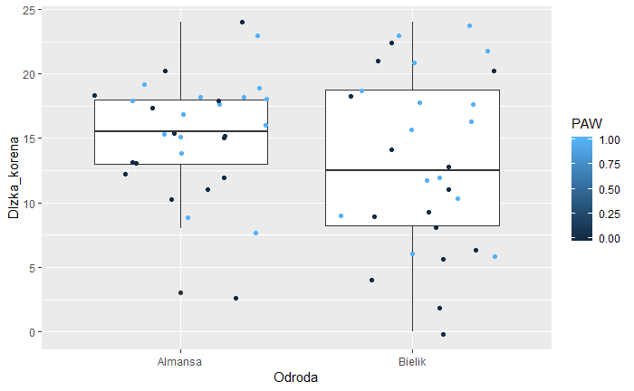

```r
library(tidyverse)
ggplot(data = kukurica_data, mapping = aes(x = Odroda, y = Dlzka_korena, color= PAW)) +
  geom_boxplot() +
  geom_jitter()
```

Vidíme, že hodnoty s použitím PAW a bez použitia PAW nam to hádže do toho isteho boxplotu, musíme ich preto oddeliť. Zárovneň zmeníme PAW zo spojitej škaly na faktor: 1 bola použitá, 0 nebola použitá.

```r
kukurica_data$Odroda = as.factor(kukurica_data$Odroda)
kukurica_data$PAW = as.factor(kukurica_data$PAW)
```

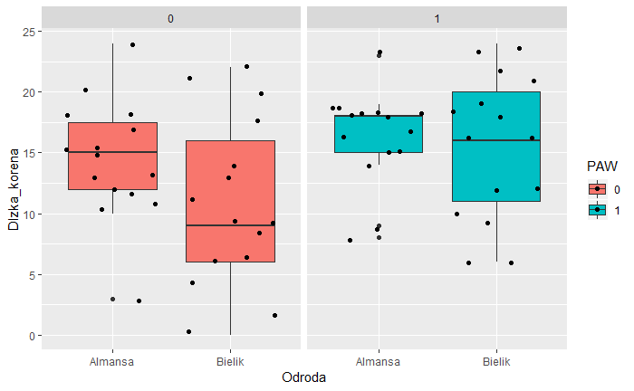

```r
ggplot(data = kukurica_data, mapping = aes(x = Odroda, y = Dlzka_korena, fill = PAW)) +
  geom_boxplot() +
  geom_jitter() +
  facet_grid(.~PAW)
```

Podarilo sa nam oddeliť hodnoty s použitím PAW od hodnot bez použitia PAW, pre lepšie vzajomne porobanie by sme však chceli mat vedla seba hodnoty pre kazdu odrodu s a bez PAW. Tiež sa nam nepáči, že jitter mieša hodnoty s a bez PAW.

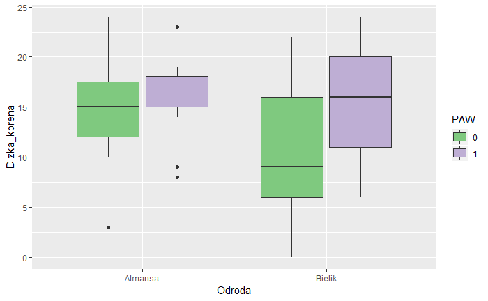

```r
library(RColorBrewer)
ggplot(data = kukurica_data, mapping = aes(x = Odroda, y = Dlzka_korena, fill = PAW)) +
  geom_boxplot() +

  scale_fill_brewer(palette = "Accent")
```

```r
NA
```

A ešte vyriešiť komplikacie s jitterom, a pridať estetické prvky.

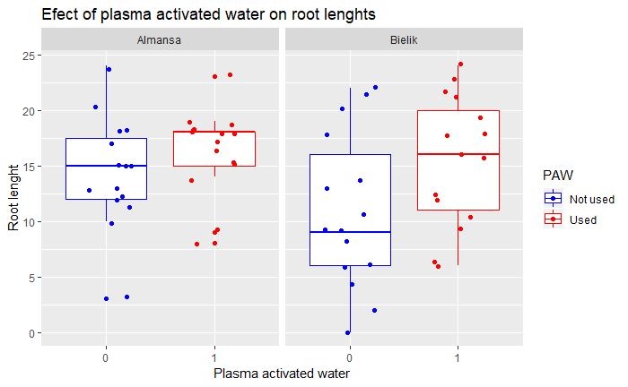

```r
library(RColorBrewer)
ggplot(data = kukurica_data) +
  scale_color_manual(values=c("blue","red"),labels=c("Not used","Used"))+
  geom_boxplot( mapping = aes(x = PAW, y = Dlzka_korena, colour = PAW)) +
  geom_jitter( mapping = aes(x = PAW, y = Dlzka_korena, colour =PAW ), width = 0.25) +

  facet_wrap(~Odroda)+
  labs(x="Plasma activated water",y="Root lenght", title= "Efect of plasma activated water on root lenghts")
```

```r
NA
```

Graf je podľa predstáv, možeme vyhodnocovať.

## Vyhodnotenie

Na porovnanie dvojfaktorového testu sa hodí t-štatistika. Pre istotu nepredpokladáme rovnosť variancii. Zároveň, hypotézu formulujeme jednostranne, teda naša nulová hypotéza hovorí, že PAW nezvyšuje dlžku koreňov.

```r
t.test(Dlzka_korena~PAW,data=kukurica_data, alternative="less", var.equal=F,subset=c(Odroda=="Bielik"))
```

```
    Welch Two Sample t-test

data:  Dlzka_korena by PAW
t = -1.9361, df = 27.383, p-value = 0.03162
alternative hypothesis: true difference in means is less than 0
95 percent confidence interval:
       -Inf -0.5551002
sample estimates:
mean in group 0 mean in group 1
       10.86667        15.46667
```

```r
t.test(Dlzka_korena~PAW,data=kukurica_data, alternative="less", var.equal=F,subset=c(Odroda=="Almansa"))
```

```
    Welch Two Sample t-test

data:  Dlzka_korena by PAW
t = -1.2068, df = 26.499, p-value = 0.1191
alternative hypothesis: true difference in means is less than 0
95 percent confidence interval:
      -Inf 0.7971389
sample estimates:
mean in group 0 mean in group 1
       14.40000        16.33333
```

Potešilo by nas, ak by variancie oboch skupin boli rovnake, lebo by sme mohli pouziť “silnejši” t test (ak tomu spravne rozumiem). Rovnost variancií overuje F-test, ktorý v Rku nachadzame ako var.test

```r
var.test(Dlzka_korena ~ Odroda, data = kukurica_data, subset=c(PAW=="1"))
```

```
    F test to compare two variances

data:  Dlzka_korena by Odroda
F = 0.40762, num df = 14, denom df = 14, p-value = 0.1045
alternative hypothesis: true ratio of variances is not equal to 1
95 percent confidence interval:
 0.1368511 1.2141410
sample estimates:
ratio of variances
         0.4076231
```

```r
var.test(Dlzka_korena ~ Odroda, data = kukurica_data, subset=c(PAW=="0"))
```

```
    F test to compare two variances

data:  Dlzka_korena by Odroda
F = 0.48934, num df = 14, denom df = 14, p-value = 0.1936
alternative hypothesis: true ratio of variances is not equal to 1
95 percent confidence interval:
 0.1642862 1.4575447
sample estimates:
ratio of variances
         0.4893409
```

```r
t.test(Dlzka_korena~PAW,data=kukurica_data, alternative="less", var.equal=T,subset=c(Odroda=="Bielik"))
t.test(Dlzka_korena~PAW,data=kukurica_data, alternative="less", var.equal=T,subset=c(Odroda=="Almansa"))
```

[output not shown]